# NYC School Survey - 2011

Nick Luthi

April 20, 2019

Load relevant data analysis packages.

```r
#install.packages(c("readr", "dplyr", "stringr", "purrr", "tidyr", "ggplot2", "reshape2"))
library(readr)
library(dplyr)
library(stringr)
library(purrr)
library(tidyr)
library(ggplot2)
library(reshape2)
```

Import data to be used for analysis.  
School survey data was downloaded from https://data.cityofnewyork.us/Education/2011-NYC-School-Survey/mnz3-dyi8. The gen_ed data contains survey data for schools that do not specifically serve populations with special needs. The spe_ed data contains survey data for schools which provide special education support for children with learning or physical disabilities.

```r
setwd("C:\\Users\\nluth\\Documents\\R\\RData\\Guided Projects\\NYC School Survey 2011\\")
combined <- read_csv("combined.csv")
gen_ed <- read_tsv("masterfile11_gened_final.txt")
spe_ed <- read_tsv("masterfile11_d75_final.txt")
```

Simplify dataframes to include a key identifier (DBN), SAT results, income demographics, and perceptions of safety, communication, engagement, and academics.  
Safety scores will be broken into four categories: aggregate, reported by parents, reported by teachers, and reported by students. Income demographics include the percentages of special education students, students receiving free/discounted lunches, and students where English is not the primary language.

```r
gen_ed_agg <- gen_ed %>%
  select(dbn, schooltype, saf_tot_11, com_tot_11, eng_tot_11, aca_tot_11)
gen_ed_p <- gen_ed %>%
  select(dbn, schooltype, saf_p_11, com_p_11, eng_p_11, aca_p_11)
gen_ed_t <- gen_ed %>%
  select(dbn, schooltype, saf_t_11, com_t_11, eng_t_11, aca_t_11)
gen_ed_s <- gen_ed %>%
  select(dbn, schooltype, saf_s_11, com_s_11, eng_s_11, aca_s_11)
gen_ed_indiv <- gen_ed %>%
  select(dbn, schooltype, saf_p_11:aca_tot_11)
combined_simp <- combined %>%
  select(DBN, boro, avg_sat_score, sped_percent, ell_percent, frl_percent) %>%
  rename(dbn = DBN)
```

Combine dataframes by using the DBN key to facilitate comparisons between perceptions and academic performance at the high school level.  
Join to keep only survey data that corresponds to schools for which we have academic performance data.

```r
agg_perc <- combined_simp %>%
  left_join(gen_ed_agg, by = "dbn") %>%
  filter(schooltype == "High School" | schooltype == "Elementary / Middle / High School" | schooltype == "Elementary / Middle / High School")
p_perc <- combined_simp %>%
  left_join(gen_ed_p, by = "dbn") %>%
  filter(schooltype == "High School" | schooltype == "Elementary / Middle / High School" | schooltype == "Elementary / Middle / High School")
t_perc <- combined_simp %>%
  left_join(gen_ed_t, by = "dbn") %>%
  filter(schooltype == "High School" | schooltype == "Elementary / Middle / High School" | schooltype == "Elementary / Middle / High School")
s_perc <- combined_simp %>%
  left_join(gen_ed_s, by = "dbn") %>%
  filter(schooltype == "High School" | schooltype == "Elementary / Middle / High School" | schooltype == "Elementary / Middle / High School")
indiv_perc <- combined_simp %>%
  left_join(gen_ed_indiv, by = "dbn") %>%
  filter(schooltype == "High School" | schooltype == "Elementary / Middle / High School" | schooltype == "Elementary / Middle / High School")
```

Create a correlation matrix to look for compelling relationships at the aggregate perception level.

```r
cor_matrix_agg <- agg_perc %>%
  select(avg_sat_score, saf_tot_11:aca_tot_11) %>%
  cor(use = "pairwise.complete.obs") %>%
  as_tibble(rownames = "variable")
```

Make scatterplots with underlying aggregate perception correlation variables to examine relationships more closely.

```r
agg_perc <- agg_perc %>%
  drop_na(avg_sat_score, dbn)

create_scatterplot <- function(x, y) {
  ggplot(data = agg_perc) +
    aes_string(x = x, y = y) +
    geom_point() +
    theme(panel.background = element_rect(fill = "white"))
}

x_var_perc <- names(agg_perc)[8:11]
y_var_sat <- "avg_sat_score"

map2(x_var_perc, y_var_sat, create_scatterplot)
```

[output not shown]

Create a correlation matrix to look for compelling relationships at the parent perception level.

```r
cor_matrix_p <- p_perc %>%
  select(avg_sat_score, saf_p_11:aca_p_11) %>%
  cor(use = "pairwise.complete.obs") %>%
  as_tibble(rownames = "variable")
```

Make scatterplots with underlying parent perception correlation variables to examine relationships more closely.

```r
p_perc <- p_perc %>%
  drop_na(avg_sat_score, dbn)

create_scatterplot <- function(x, y) {
  ggplot(data = p_perc) +
    aes_string(x = x, y = y) +
    geom_point() +
    theme(panel.background = element_rect(fill = "white"))
}

x_var_perc <- names(p_perc)[8:11]
y_var_sat <- "avg_sat_score"

map2(x_var_perc, y_var_sat, create_scatterplot)
```

[output not shown]

Create a correlation matrix to look for compelling relationships at the teacher perception level.

```r
cor_matrix_t <- t_perc %>%
  select(avg_sat_score, saf_t_11:aca_t_11) %>%
  cor(use = "pairwise.complete.obs") %>%
  as_tibble(rownames = "variable")
```

Make scatterplots with underlying teacher perception correlation variables to examine relationships more closely.

```r
t_perc <- t_perc %>%
  drop_na(avg_sat_score, dbn)

create_scatterplot <- function(x, y) {
  ggplot(data = t_perc) +
    aes_string(x = x, y = y) +
    geom_point() +
    theme(panel.background = element_rect(fill = "white"))
}

x_var_perc <- names(t_perc)[8:11]
y_var_sat <- "avg_sat_score"

map2(x_var_perc, y_var_sat, create_scatterplot)
```

[output not shown]

Create a correlation matrix to look for compelling relationships at the student perception level.

```r
cor_matrix_s <- s_perc %>%
  select(avg_sat_score, saf_s_11:aca_s_11) %>%
  cor(use = "pairwise.complete.obs") %>%
  as_tibble(rownames = "variable")
```

Make scatterplots with underlying student perception correlation variables to examine relationships more closely.

```r
s_perc <- s_perc %>%
  drop_na(avg_sat_score, dbn)

create_scatterplot <- function(x, y) {
  ggplot(data = s_perc) +
    aes_string(x = x, y = y) +
    geom_point() +
    theme(panel.background = element_rect(fill = "white"))
}

x_var_perc <- names(s_perc)[8:11]
y_var_sat <- "avg_sat_score"

map2(x_var_perc, y_var_sat, create_scatterplot)
```

[output not shown]

Create a correlation matrix heat map to look for the most compelling relationships relative to the survey response groups.

```r
cor_matrix_indiv <- indiv_perc %>%
  select(avg_sat_score, saf_p_11:aca_tot_11) %>%
  cor(use = "pairwise.complete.obs") %>%
  as_tibble(rownames = "variable")

get_upper_tri <- function(matrix) {
  matrix[lower.tri(matrix)] <- NA
  return(matrix)
}

upper_tri_indiv <- get_upper_tri(cor_matrix_indiv)

melted_cor_matrix_indiv <- melt(upper_tri_indiv, na.rm = TRUE) %>%
  drop_na()
colnames(melted_cor_matrix_indiv) <- c("Avg SAT Score", "School Perceptions", "Value")

ggplot(data = melted_cor_matrix_indiv) +
  aes(x = `Avg SAT Score`, y = `School Perceptions`, fill = Value) +
  geom_tile(color = "white") +
  scale_fill_gradient2(low = "blue", high = "red", mid = "white", midpoint = 0, limit = c(-1,1), space = "Lab", name = "Pearson Correlation") +
  theme_minimal() +
  theme(axis.text.x = element_text(angle = 45, vjust = 1, size = 12, hjust = 1)) +
  coord_fixed()
```

[output not shown]

Reshape data to investigate differences between student, teacher, and parent responses to survey questions. Enhance the readability of the response types and questions.

```r
indiv_perc_gather <- indiv_perc %>%
  gather(key = "survey_question", value = score, saf_p_11:aca_tot_11)

indiv_perc_gather <- indiv_perc_gather %>%
  mutate(response_type = str_sub(survey_question, 4, 6)) %>%
  mutate(question = str_sub(survey_question, 1, 3))

indiv_perc_gather <- indiv_perc_gather %>%
  mutate(response_type = if_else(response_type == "_p_", "Parent",
                                 if_else(response_type == "_t_", "Teacher",
                                         if_else(response_type == "_s_", "Student",
                                                 if_else(response_type == "_to", "All Respondents", "NA")))))

indiv_perc_gather <- indiv_perc_gather %>%
  mutate(question = if_else(question == "saf", "Safety",
                               if_else(question == "com", "Communication",
                                       if_else(question == "aca", "Academic",
                                               if_else(question == "eng", "Engagement", "NA")))))
```

Create a boxplot to see how the three groups of respondents answered the questions.

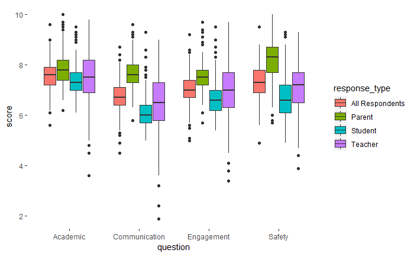

```r
ggplot(data = indiv_perc_gather) +
  aes(x = question, y = score, fill = response_type) +
  theme(panel.background = element_rect(fill = "white")) +
  geom_boxplot()
```